# Python数据处理

## 01 Python介绍

主讲人：丁平尖

## 我是谁

- https://kdding.github.io/

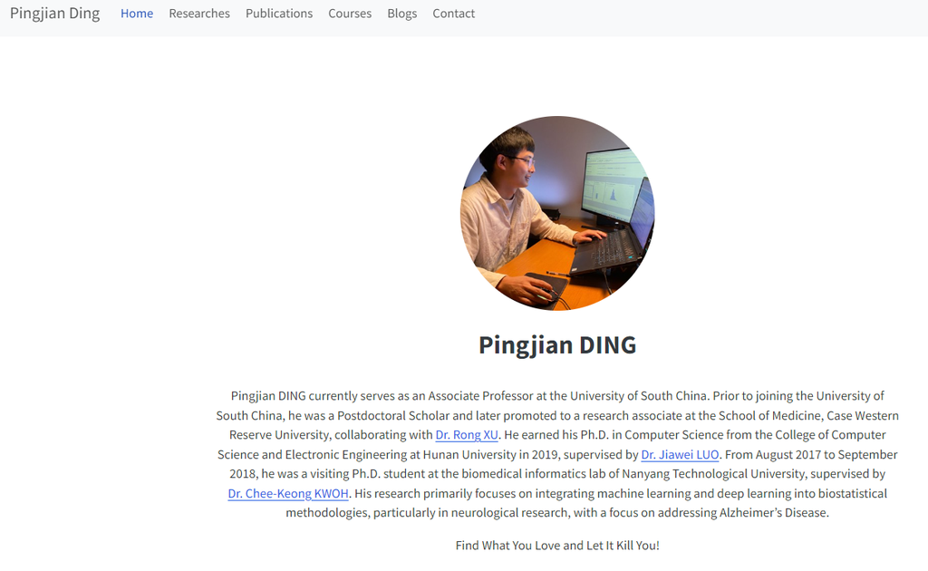

## 为什么没有教材？

- 网上有电子版
  - https://wesmckinney.com/book/
- 大篇幅讲述函数和代码
  - 完全记不住
- 书厚但不够丰富
- 贵

[figure not shown]

## 数据科学彻底改变了这个世界

[figure not shown]

## 课程目标

- 具有Python编程方面的背景
- 介绍学术界/工业界流行的数据分析工具
- 学习如何阅读文档并快速使用新工具
- 学习基本的分布式计算框架、深度学习框架

These tools will be obsolete some day ... ... but not your ability to learn new frameworks and solve problems!

## 课程内容

- Python介绍
  - Data types, functions, Jupyter, classes, objects
- 数值计算与数据可视化
  - Numpy, scipy, matplotlib
- 结构化数据处理
  - Regular expressions, retrieving web data, SQL, Python pandas, APIs
- 大数据和并行编程
  - Basics of the UNIX command line, Hadoop, Spark, PyTorch

## Python书籍推荐

[figure not shown]

- Think Python
  - https://greenteapress.com/wp/think-python-2e/
- Python for Everybody
  - https://www.py4e.com/book.php

## 学习第一步

- 选择一个Python IDE或编辑器
  - 文本编辑器，Jupyter、Pycharm或VS Code
- 熟悉jupyter
  - https://docs.jupyter.org/en/latest/start/index.html
- 熟悉Pycharm
  - https://www.jetbrains.com/help/pycharm/jupyter-notebook-support.html
- 熟悉VS Code
  - https://code.visualstudio.com/docs/datascience/jupyter-notebooks

本课程将全部使用Python3

## Python简介

- Python是一种**动态类型**、**解释型**编程语言
  - 由Guido van Rossum于1991年创建
  - 由Python软件基金会维护
  - 动态类型：在许多编程语言中，当你声明一个变量时，必须指定变量的类型（例如：int、double、Boolean，string）。而在Python中则不需要这样做。
  - 有些编程语言（如C/C++和Java）是编译型的：编写代码，然后通过编译生成一个可运行的程序。相比之下，Python是解释型的：一个称为解释器的程序逐行运行我们的代码。
- 设计理念：简洁、可读的代码
- Python语法与R、Java、C/C++、MATLAB不同
  - 使用空白符分隔
  - 较少使用括号、分号等符号

## Python简介

```
for (i in 1:10) {
  print(i)
}
```

```
#include <iostream>

int main() {
    for (int i = 1; i <= 10; i++) {
        std::cout << i << std::endl;
    }
    return 0;
}
```

```
for i = 1:10
    disp(i)
end
```

```
for i in range(1, 11):
    print(i)
```

## Python简介

```
for (i in 1:10) {
  print(i)
}
```

**R**

```
#include <iostream>

int main() {
    for (int i = 1; i <= 10; i++) {
        std::cout << i << std::endl;
    }
    return 0;
}
```

**C++**

```
for i = 1:10
    disp(i)
end
```

**Matlab**

```
for i in range(1, 11):
    print(i)
```

**Python**

使用空白符分隔；较少使用括号、分号等符号

## 运行Python

- 如何运行Python
  - Python解释器
  - Jupyter：https://jupyter.org/
  - PythonAnywhere：https://www.pythonanywhere.com/
  - PyCharm：https://www.jetbrains.com/pycharm/
  - Visual Studio Code：https://code.visualstudio.com/
- 作业以Jupyter Notebook的形式提交（.ipynb）
  - Jupyter安装：https://docs.jupyter.org/en/latest/install.html
  - 建议使用Anaconda安装Jupyter和管理环境：https://anaconda.com/

## Python Interpreter on the Command Line

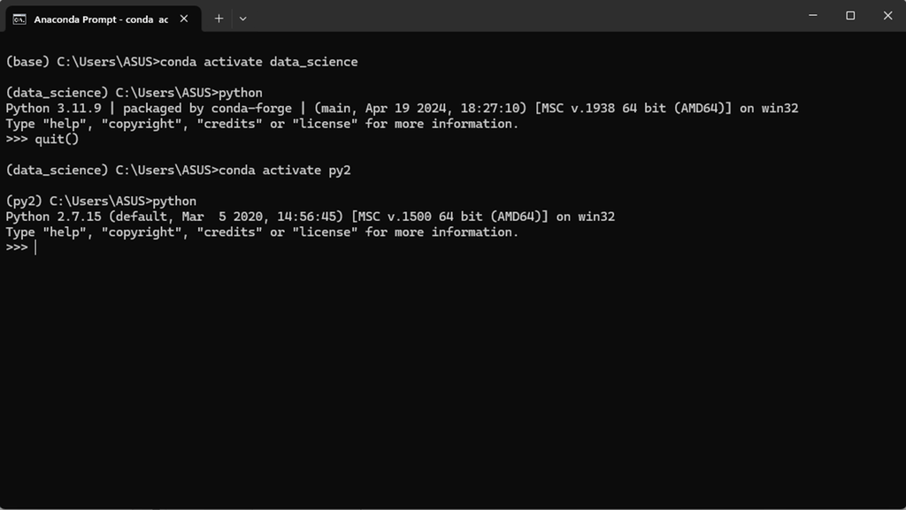

## Python Interpreter on the Command Line

[figure not shown]

## Python in Jupyter

- 安装Jupyter
  - https://jupyterlab.readthedocs.io/en/stable/getting_started/installation.html

[figure not shown]

## Jupyter Notebook和Jupyter Lab

- Jupyter Notebook是Jupyter项目的早期版本，提供了一个基于Web的交互式计算环境。

[figure not shown]

## Jupyter Notebook和Jupyter Lab

- Jupyter Lab是Jupyter项目的新一代交互式计算环境，提供了更加现代和灵活的用户界面。Jupyter Lab不仅包含了Console、terminal和其他工具集，可以在Jupyter Lab中同时打开多个工具进行操作。

[figure not shown]

## 启动Jupyter

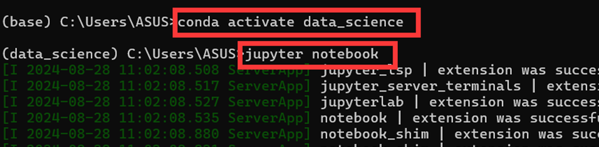

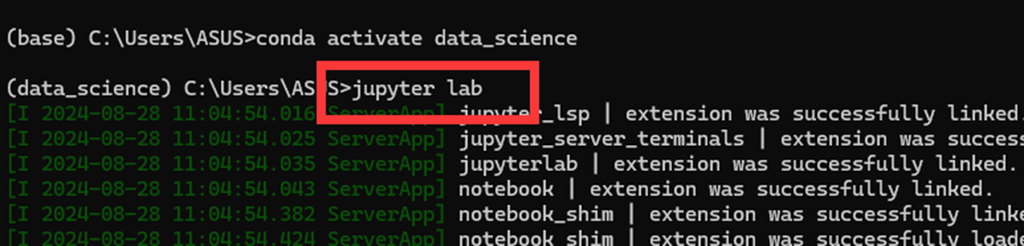

## Jupyter

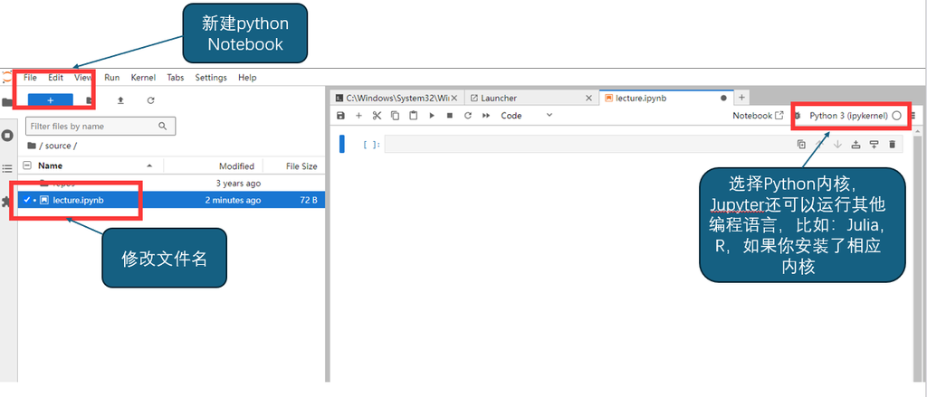

## 第一个Python代码

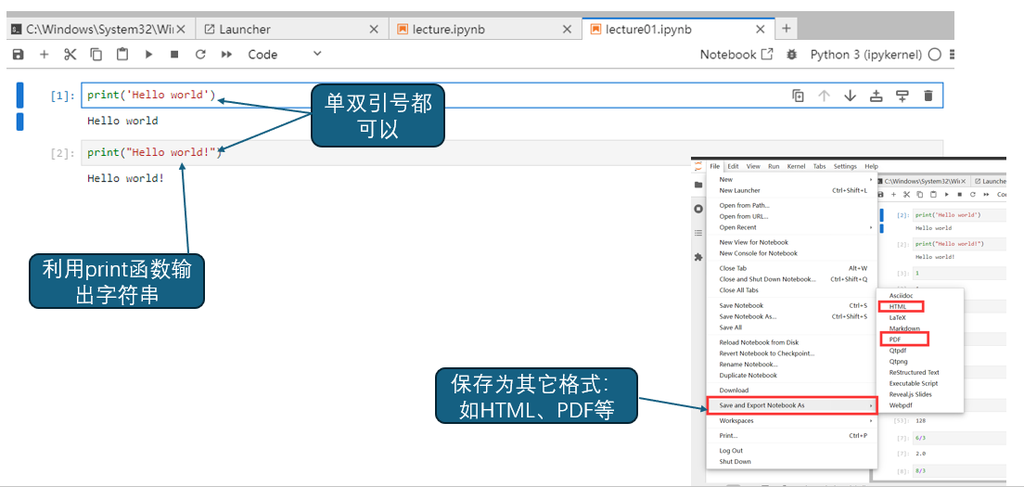

## PyCharm

- https://www.jetbrains.com/help/pycharm/jupyter-notebook-support.html

[figure not shown]

**PyCharm专业版才支持Jupyter Notebook**

## PyCharm

- File > Settings > Project Notes > Python Interpreter

[figure not shown]

## AI Assistant

- AI Assistant
  - https://www.jetbrains.com/help/pycharm/ai-assistant.html
- Github Copilot
  - https://github.com/features/copilot
- Codeium
  - https://codeium.com/

## AI Assistant

- File > Settings > Plugins

[figure not shown]

## Codeium

[figure not shown]

## Version control

- 版本控制
  - https://www.jetbrains.com/help/pycharm/version-control-integration.html
- 不熟悉git的同学，可以到Bilibili上找找相关介绍视频

[figure not shown]

## 导出Html文件

- 打开终端，激活相应环境
- 安装nbconvert
  - pip install nbconvert
- 将.ipynb文件导出为HTML
  - jupyter nbconvert --to html lecture01.ipynb

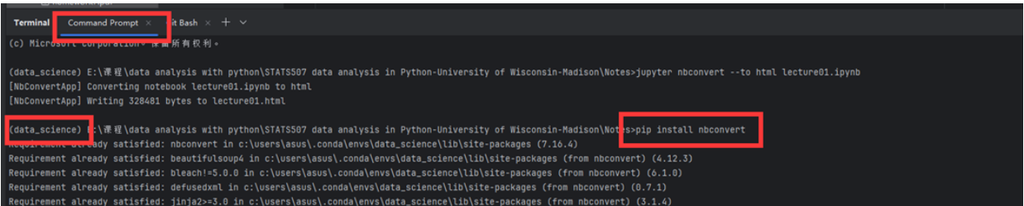

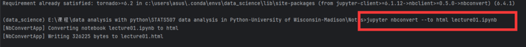

## VS Code

- https://code.visualstudio.com/docs

[figure not shown]

## VS Code

- 在VS Code中安装Python和Jupyter扩展

[figure not shown]

## VS Code

- 选择相应的解释器

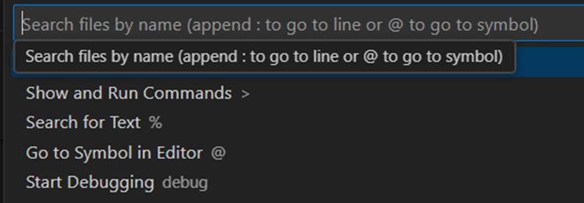

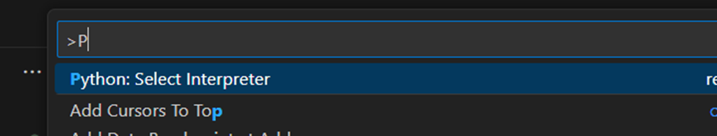

## VS Code

- 选择相应的环境

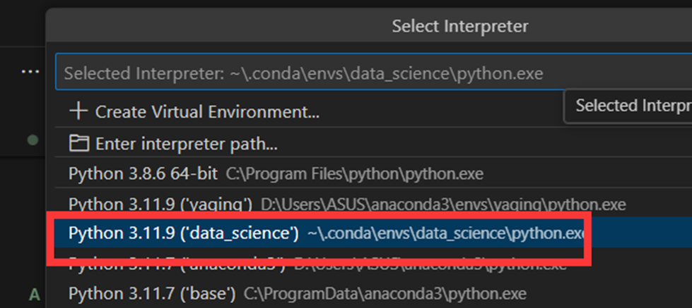

## VS Code

- Terminal

[figure not shown]

## VS Code

- Version control and AI Assistant

[figure not shown]

## Python中的算术

```python
1 + 2 # 1 plus 2
```

```
3
```

```python
2 * 3 # 2 times 3
```

```
6
```

```python
2 ** 7  # 2 to the power of 7
```

```
128
```

```python
8 / 3 # 8 divided by 3
```

```
2.6666666666666665
```

```python
8 // 3 # 8 divided by 3 without remainder
```

```
2
```

```python
8 % 3 # 8 modulo 3
```

```
2
```

## 数据类型

- 程序处理不同值，将给予不同的类型；
  - 例如：
    - 值 42 是一个整数
    - 值2.71828 是一个浮点数（即小数）
    - 值 “bird” 是一个字符串（即一串字符）
- 变量的类型决定了我们可以执行或不能执行的操作。
  - 例如，2 * 3 是合理的，但 ‘cat’*‘dog’ 是什么意思？

## Variables in Python

```python
# 与其它编程语言不同的是，Python自动指定变量类型
# 这种方式叫做 Duck Typing
mystring = "hello world!"
approxi_pi = 3.1415926
number_of_planet = 9
```

```python
# 你可以使用 type() 函数来查看变量的类型
type(mystring)
```

```
str
```

```python
type(approxi_pi)
```

```
float
```

```python
type(number_of_planet)
```

```
int
```

## Variables in Python

- Python变量类型的转化

```python
approxi_pi = 3.1415926
type(approxi_pi)
```

```
float
```

```python
# convert a float to an integer
pi_int = int(approxi_pi)
type(pi_int)
```

```
int
```

```python
# convert an string to an integer
int_from_string = int('123456')
type(int_from_string)
```

```
int
```

```python
int_from_string
```

```
123456
```

```python
# 但是有些转换是没有意义的
goat_int = int('goat')
```

```
---------------------------------------------------------------------------
ValueError                                Traceback (most recent call last)
Cell In[15], line 2
      1 # 但是有些转换是没有意义的
----> 2 goat_int = int('goat')

ValueError: invalid literal for int() with base 10: 'goat'
```

## 一些字符串运算

```python
# 一些运算也是没有意义的
'dog' * 'cat'
```

```
---------------------------------------------------------------------------
TypeError                                 Traceback (most recent call last)
Cell In[16], line 2
      1 # 一些运算也是没有意义的
----> 2 'dog' * 'cat'

TypeError: can't multiply sequence by non-int of type 'str'
```

```python
# concatenation of two strings
'dog' + 'cat'
```

```
'dogcat'
```

```python
# string concatenation with multiplication
'dog' * 3
```

```
'dogdogdog'
```

## Python中的注释

- 两种注释'#'和''' '''

```python
# This is a comment.
# Python doesn't process this line.
euler = 2.71828
'''Triple quotes let you write a multiline like this one.
Everything between the quotes is part of the comment.
'''
print(euler)
```

[output not shown]

## 作业

- 安装并注册Anaconda、Jupyter、PyCharm（专业版）和VS Code
- 安装并注册GitHub和Codeium
- 阅读PyCharm或VS Code的技术文档